# Chapter 3 Community composition

## 3.1 Metagenomics

```r
load("resources/metagenomics/data_filtered.Rdata")
```

### 3.1.1 Taxonomy overview

**Number of MAGs**

```r
genome_metadata %>%
  nrow()%>%
  cat()
```

```
135
```

**Number of Archaea phyla**

```r
genome_metadata %>%
  filter(domain == "Archaea")%>%
  dplyr::select(phylum) %>%
  unique() %>%
  pull() %>%
  length()%>%
  cat()
```

```
0
```

**Number of Bacteria phyla**

```r
genome_metadata %>%
  filter(domain == "Bacteria")%>%
  dplyr::select(phylum) %>%
  unique() %>%
  pull() %>%
  length()%>%
  cat()
```

```
13
```

#### 3.1.1.1 Phylum level

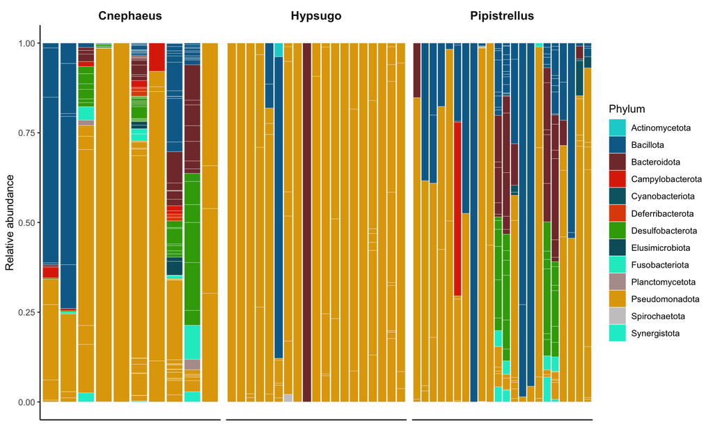

```r
genome_counts_filt %>%
  mutate_at(vars(-genome),  ~ . / sum(.)) %>%
  pivot_longer(-genome, names_to = "sample", values_to = "count") %>%
  left_join(., genome_metadata, by = join_by(genome == genome)) %>%
  left_join(., sample_metadata, by = join_by(sample == sample)) %>%
  filter(count > 0) %>% #filter 0 counts
  ggplot(., aes(
    x = sample,
    y = count,
    fill = phylum,
    group = phylum
  )) +
  geom_bar(stat = "identity",
           colour = "white",
           linewidth = 0.1) +
  scale_fill_manual(values = phylum_colors) +
  facet_nested( ~ factor(
    Species,
    labels = c("Eb" = "Cnephaeus", "Ha" = "Hypsugo", "Pk" = "Pipistrellus")
  ), scales = "free") +
  guides(fill = guide_legend(ncol = 1)) +
  theme(
    axis.text.x = element_blank(),
    axis.ticks.x = element_blank(),
    axis.title.x = element_blank(),
    panel.background = element_blank(),
    panel.border = element_blank(),
    panel.grid.major = element_blank(),
    panel.grid.minor = element_blank(),
    strip.background = element_rect(fill = "white"),
    strip.text = element_text(
      size = 12,
      lineheight = 0.6,
      face = "bold"
    ),
    axis.line = element_line(
      linewidth = 0.5,
      linetype = "solid",
      colour = "black"
    )
  ) +
  labs(fill = "Phylum", y = "Relative abundance", x = "Samples")
```

**Grouping low-abundance bacteria**

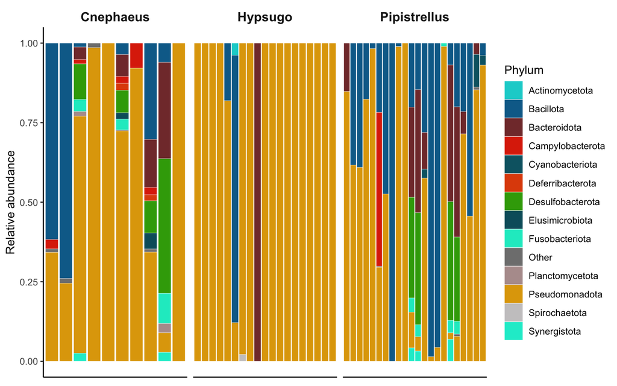

```r
p1 <- genome_counts_filt %>%
  mutate_at(vars(-genome), ~ . / sum(.)) %>%
  pivot_longer(-genome, names_to = "sample", values_to = "count") %>%
  left_join(genome_metadata, by = join_by(genome == genome)) %>%
  left_join(sample_metadata, by = join_by(sample == sample)) %>%
  filter(count > 0) %>%
group_by(sample, phylum) %>%
  mutate(total_abundance = sum(count)) %>%
  ungroup() %>%
  mutate(phylum = if_else(total_abundance < 0.01, "Other", phylum)) %>%
  group_by(sample, phylum, Species) %>%
  summarise(count = sum(count), .groups = "drop") %>%
   ggplot(aes(
    x = sample,
    y = count,
    fill = phylum,
    group = phylum
  )) +
  geom_bar(stat = "identity",
           colour = "white",
           linewidth = 0.1) +
  scale_fill_manual(values = c(phylum_colors, "Other" = "grey50"),
                    drop = FALSE)+
  facet_nested(~ factor(
    Species,
    labels = c("Eb" = "Cnephaeus", "Ha" = "Hypsugo", "Pk" = "Pipistrellus")
  ), scales = "free") +
  guides(fill = guide_legend(ncol = 1)) +
  theme(
    axis.text.x = element_blank(),
    axis.ticks.x = element_blank(),
    axis.title.x = element_blank(),
    panel.background = element_blank(),
    panel.border = element_blank(),
    panel.grid.major = element_blank(),
    panel.grid.minor = element_blank(),
    strip.background = element_rect(fill = "white"),
    strip.text = element_text(size = 12, lineheight = 0.6, face = "bold"),
    axis.line = element_line(linewidth = 0.5, linetype = "solid", colour = "black")
  ) +
  labs(fill = "Phylum", y = "Relative abundance", x = "Samples")
#ggsave("community_plot_grouped_metagenomics.pdf", plot = p1, width = 12, height = 6)
p1
```

**Phylum relative abundances**

```r
phylum_summary <- genome_counts_filt %>%
  mutate_at(vars(-genome),~./sum(.)) %>%
  pivot_longer(-genome, names_to = "sample", values_to = "count") %>%
  left_join(sample_metadata, by = join_by(sample == sample)) %>%
  left_join(genome_metadata, by = join_by(genome == genome)) %>%
  group_by(sample,phylum,Species) %>%
  summarise(relabun=sum(count))
```

```r
phylum_summary %>%
  group_by(phylum) %>%
  summarise(
    Total_mean = mean(relabun * 100, na.rm = T),
    Total_sd = sd(relabun * 100, na.rm = T),
    Eb_mean = mean(relabun[Species == "Eb"] * 100, na.rm = T),
    Eb_sd = sd(relabun[Species == "Eb"] * 100, na.rm = T),
    Ha_mean = mean(relabun[Species == "Ha"] * 100, na.rm = T),
    Ha_sd = sd(relabun[Species == "Ha"] * 100, na.rm = T),
    Pk_mean = mean(relabun[Species == "Pk"] * 100, na.rm = T),
    Pk_sd = sd(relabun[Species == "Pk"] * 100, na.rm = T)
  ) %>%
  mutate(
    Total = str_c(round(Total_mean, 3), "±", round(Total_sd, 3)),
    Cnephaeus = str_c(round(Eb_mean, 3), "±", round(Eb_sd, 3)),
    Hypsugo = str_c(round(Ha_mean, 3), "±", round(Ha_sd, 3)),
    Pipistrellus = str_c(round(Pk_mean, 3), "±", round(Pk_sd, 3))
  ) %>%
  arrange(-Eb_mean) %>%
  dplyr::select(phylum,
                Total,
                Cnephaeus,
                Hypsugo,
                Pipistrellus) %>%
  tt()
```

| phylum | Total | Cnephaeus | Hypsugo | Pipistrellus |
| --- | --- | --- | --- | --- |
| Pseudomonadota | 68.255±37.904 | 63.683±35.64 | 89.049±29.599 | 52.374±38.209 |
| Bacillota | 17.862±28.832 | 17.716±28.111 | 5.375±19.493 | 28.713±32.41 |
| Desulfobacterota | 3.981±10.582 | 7.227±13.106 | 0±0 | 5.944±13.024 |
| Bacteroidota | 6.774±17.384 | 5.695±9.903 | 5.263±22.942 | 8.569±14.844 |
| Fusobacteriota | 0.694±1.785 | 1.818±3.061 | 0±0 | 0.781±1.589 |
| Campylobacterota | 1.288±6.836 | 1.731±2.428 | 0±0 | 2.198±10.309 |
| Elusimicrobiota | 0.141±0.755 | 0.72±1.643 | 0±0 | 0±0 |
| Synergistota | 0.405±1.282 | 0.562±1.116 | 0±0 | 0.684±1.771 |
| Planctomycetota | 0.086±0.454 | 0.44±0.985 | 0±0 | 0±0 |
| Deferribacterota | 0.08±0.4 | 0.407±0.861 | 0±0 | 0±0 |
| Actinomycetota | 0.075±0.534 | 0±0 | 0.201±0.876 | 0±0 |
| Cyanobacteriota | 0.318±1.537 | 0±0 | 0±0 | 0.737±2.302 |
| Spirochaetota | 0.041±0.296 | 0±0 | 0.111±0.486 | 0±0 |

**Number of different phyla in each bat species**

```r
phylum_summary <- genome_counts_filt %>%
  mutate_at(vars(-genome),~./sum(.)) %>%
  pivot_longer(-genome, names_to = "sample", values_to = "count") %>%
  left_join(sample_metadata, by = join_by(sample == sample)) %>%
  left_join(genome_metadata, by = join_by(genome == genome)) %>%
  group_by(sample,domain,phylum,Species) %>%
  summarise(relabun=sum(count))

phylum_summary %>%
  filter(relabun > 0) %>%
  group_by(Species,domain) %>%
  summarise(n_phyla = n_distinct(phylum)) %>%
  tt()
```

| Species | domain | n_phyla |
| --- | --- | --- |
| Eb | Bacteria | 10 |
| Ha | Bacteria | 5 |
| Pk | Bacteria | 8 |

#### 3.1.1.2 Family level

**Percentange of families in each group**

```r
family_summary <- genome_counts_filt %>%
  mutate_at(vars(-genome),~./sum(.)) %>%
  pivot_longer(-genome, names_to = "sample", values_to = "count") %>%
  left_join(sample_metadata, by = join_by(sample == sample)) %>%
  left_join(., genome_metadata, by = join_by(genome == genome)) %>%
  group_by(sample,family, Species) %>%
  summarise(relabun=sum(count))
```

```r
family_summary %>%
  group_by(family) %>%
  summarise(
    Eb_mean = mean(relabun[Species == "Eb"] * 100, na.rm = T),
    Eb_sd = sd(relabun[Species == "Eb"] * 100, na.rm = T),
    Ha_mean = mean(relabun[Species == "Ha"] * 100, na.rm = T),
    Ha_sd = sd(relabun[Species == "Ha"] * 100, na.rm = T),
    Pk_mean = mean(relabun[Species == "Pk"] * 100, na.rm = T),
    Pk_sd = sd(relabun[Species == "Pk"] * 100, na.rm = T)
  ) %>%
  mutate(
    Cnephaeus = str_c(round(Eb_mean, 3), "±", round(Eb_sd, 3)),
    Hypsugo = str_c(round(Ha_mean, 3), "±", round(Ha_sd, 3)),
    Pipistrellus = str_c(round(Pk_mean, 3), "±", round(Pk_sd, 3))
  ) %>%
  arrange(-Eb_mean, -Ha_mean) %>%
  dplyr::select(family, Cnephaeus, Hypsugo, Pipistrellus) %>%
  tt()
```

| family | Cnephaeus | Hypsugo | Pipistrellus |
| --- | --- | --- | --- |
| Diplorickettsiaceae | 33.448±40.33 | 24.089±41.769 | 10.097±24.365 |
| Enterobacteriaceae | 17.987±30.59 | 8.13±20.144 | 14.369±22.519 |
| Mycoplasmataceae | 8.829±18.638 | 4.422±19.277 | 0±0 |
| Vibrionaceae | 7.534±23.723 | 5.863±11.437 | 5.576±18.175 |
| Desulfovibrionaceae | 6.023±11.116 | 0±0 | 4.561±9.963 |
| Enterococcaceae | 4.692±10.65 | 0.602±2.624 | 3.243±11.687 |
| Dysgonomonadaceae | 2.721±6.637 | 0±0 | 3.84±7.171 |
| Aeromonadaceae | 1.626±4.965 | 5.844±13.778 | 0±0 |
| Leptotrichiaceae | 1.611±3.041 | 0±0 | 0.733±1.597 |
| Helicobacteraceae | 1.544±2.452 | 0±0 | 2.198±10.309 |
| Halomonadaceae | 1.351±4.273 | 0±0 | 0±0 |
| Bacteroidaceae | 1.332±4.049 | 0±0 | 0.32±1.501 |
| Metamycoplasmataceae | 1.211±3.83 | 0±0 | 3.313±15.537 |
| Adiutricaceae | 1.204±2.22 | 0±0 | 1.383±3.308 |
|  | 0.963±1.591 | 0±0 | 0.264±0.67 |
| Tannerellaceae | 0.857±1.866 | 0±0 | 2.727±6.739 |
| Christensenellaceae | 0.846±2.495 | 0±0 | 0±0 |
| Elusimicrobiaceae | 0.612±1.589 | 0±0 | 0±0 |
| Synergistaceae | 0.562±1.116 | 0±0 | 0.684±1.771 |
| Rhodocyclaceae | 0.548±1.298 | 0±0 | 0±0 |
| SZUA-567 | 0.44±0.985 | 0±0 | 0±0 |
| Lachnospiraceae | 0.418±0.958 | 0±0 | 0.787±2.395 |
| Burkholderiaceae | 0.411±1.103 | 4.849±20.891 | 2.299±6.108 |
| Mucispirillaceae | 0.407±0.861 | 0±0 | 0±0 |
| Erysipelotrichaceae | 0.332±0.85 | 0±0 | 0.285±0.809 |
| Ruminococcaceae | 0.304±0.552 | 0±0 | 0.417±1.346 |
| UBA932 | 0.297±0.484 | 0±0 | 0.991±2.93 |
| Rikenellaceae | 0.286±0.69 | 0±0 | 0±0 |
| Oscillospiraceae | 0.253±0.8 | 0±0 | 0.883±2.557 |
| Fusobacteriaceae | 0.207±0.458 | 0±0 | 0.048±0.225 |
| Weeksellaceae | 0.204±0.644 | 5.263±22.942 | 0.692±3.245 |
| Campylobacteraceae | 0.187±0.334 | 0±0 | 0±0 |
| Acutalibacteraceae | 0.178±0.296 | 0±0 | 0.074±0.24 |
| CAG-508 | 0.176±0.555 | 0±0 | 0±0 |
| Endomicrobiaceae | 0.108±0.31 | 0±0 | 0±0 |
| UBA660 | 0.083±0.229 | 0±0 | 0±0 |
| CAG-239 | 0.081±0.257 | 0±0 | 0±0 |
| Acetobacteraceae | 0.053±0.103 | 3.841±16.741 | 0.008±0.038 |
| Anaerotignaceae | 0.039±0.125 | 0±0 | 0.208±0.565 |
| Beijerinckiaceae | 0.036±0.114 | 0±0 | 0.124±0.448 |
| Rickettsiaceae | 0±0 | 19.201±34.543 | 5.196±18.606 |
| Chromatiaceae | 0±0 | 10.155±30.073 | 0±0 |
| Neisseriaceae | 0±0 | 1.988±6.869 | 0±0 |
| Morganellaceae | 0±0 | 1.976±8.178 | 4.1±12.636 |
| Rhizobiaceae | 0±0 | 1.925±5.939 | 0.839±3.054 |
| Anaplasmataceae | 0±0 | 1.189±3.02 | 3.294±14.883 |
| Streptococcaceae | 0±0 | 0.351±1.529 | 1.768±8.172 |
| Micrococcaceae | 0±0 | 0.201±0.876 | 0±0 |
| WRBN01 | 0±0 | 0.111±0.486 | 0±0 |
| Clostridiaceae | 0±0 | 0±0 | 0.206±0.966 |
| Cyanobiaceae | 0±0 | 0±0 | 0.11±0.421 |
| Gemellaceae | 0±0 | 0±0 | 1.591±4.739 |
| Microcoleaceae | 0±0 | 0±0 | 0.628±2.159 |
| Mycoplasmoidaceae | 0±0 | 0±0 | 15.785±29.329 |
| Pasteurellaceae | 0±0 | 0±0 | 6.36±15.418 |

#### 3.1.1.3 Genus level

**Percetange of genera in each group**

```r
genus_summary <- genome_counts_filt %>%
  mutate_at(vars(-genome),  ~ . / sum(.)) %>%
  pivot_longer(-genome, names_to = "sample", values_to = "count") %>%
  left_join(sample_metadata, by = join_by(sample == sample)) %>%
  left_join(genome_metadata, by = join_by(genome == genome)) %>%
  group_by(sample, phylum, genus, Species) %>%
  summarise(relabun = sum(count))

genus_summary %>%
  group_by(genus) %>%
  summarise(
    Eb_mean = mean(relabun[Species == "Eb"] * 100, na.rm = T),
    Eb_sd = sd(relabun[Species == "Eb"] * 100, na.rm = T),
    Ha_mean = mean(relabun[Species == "Ha"] * 100, na.rm = T),
    Ha_sd = sd(relabun[Species == "Ha"] * 100, na.rm = T),
    Pk_mean = mean(relabun[Species == "Pk"] * 100, na.rm = T),
    Pk_sd = sd(relabun[Species == "Pk"] * 100, na.rm = T)
  ) %>%
  mutate(
    Cnephaeus = str_c(round(Eb_mean, 3), "±", round(Eb_sd, 3)),
    Hypsugo = str_c(round(Ha_mean, 3), "±", round(Ha_sd, 3)),
    Pipistrellus = str_c(round(Pk_mean, 3), "±", round(Pk_sd, 3))
  ) %>%
  arrange(-Eb_mean, -Ha_mean) %>%
  dplyr::select(genus, Cnephaeus, Hypsugo, Pipistrellus) %>%
  tt()
```

| genus | Cnephaeus | Hypsugo | Pipistrellus |
| --- | --- | --- | --- |
| Aquirickettsiella | 33.448±40.33 | 24.089±41.769 | 10.097±24.365 |
| Spiroplasma | 8.747±18.476 | 0±0 | 0±0 |
| Vibrio | 7.534±23.723 | 5.863±11.437 | 5.576±18.175 |
| Enterococcus | 4.692±10.65 | 0.602±2.624 | 3.243±11.687 |
| Jejubacter | 4.268±9 | 0±0 | 0±0 |
| Escherichia | 3.416±10.802 | 0±0 | 0.317±1.488 |
| Pseudocitrobacter | 3.293±9.507 | 0±0 | 0.006±0.028 |
| Frigididesulfovibrio | 2.803±4.353 | 0±0 | 1.129±2.876 |
| Dysgonomonas | 2.721±6.637 | 0±0 | 3.84±7.171 |
| Serratia | 2.389±7.462 | 6.416±19.813 | 2.331±10.5 |
| WRHT01 | 1.656±3.44 | 0±0 | 2.264±5.141 |
| Aeromonas | 1.626±4.965 | 5.844±13.778 | 0±0 |
| Sebaldella | 1.611±3.041 | 0±0 | 0.733±1.597 |
| FLUQ01 | 1.563±3.576 | 0±0 | 1.167±2.563 |
| Helicobacter_C | 1.544±2.452 | 0±0 | 0±0 |
| Zymobacter | 1.351±4.273 | 0±0 | 0±0 |
| UBA710 | 1.211±3.83 | 0±0 | 3.313±15.537 |
| Adiutrix | 1.204±2.22 | 0±0 | 1.383±3.308 |
| Proteus | 1.195±3.78 | 0±0 | 5.613±15.739 |
| Bacteroides | 1.053±3.329 | 0±0 | 0.32±1.501 |
| Tannerella | 0.857±1.866 | 0±0 | 1.972±5.493 |
| QANA01 | 0.846±2.495 | 0±0 | 0±0 |
| CALYQQ01 | 0.809±1.751 | 0±0 | 0±0 |
| Enterobacillus | 0.787±1.934 | 0±0 | 0±0 |
| GCA-022846635 | 0.706±1.692 | 0±0 | 0±0 |
| Citrobacter | 0.653±1.233 | 0±0 | 0.11±0.405 |
|  | 0.638±1.527 | 3.27±16.196 | 0.928±2.976 |
| UBA1174 | 0.497±1.233 | 0±0 | 0±0 |
| Klebsiella | 0.471±1.038 | 0±0 | 4.061±13.147 |
| JAJBSZ01 | 0.44±0.985 | 0±0 | 0±0 |
| Saezia | 0.411±1.103 | 0±0 | 0.574±1.417 |
| Breznakia | 0.332±0.85 | 0±0 | 0.285±0.809 |
| JAJQAW01 | 0.286±0.69 | 0±0 | 0±0 |
| UBA1794 | 0.279±0.732 | 0±0 | 0±0 |
| JAAYCI01 | 0.27±0.56 | 0±0 | 0.042±0.199 |
| Fusobacterium | 0.207±0.458 | 0±0 | 0.048±0.225 |
| Apibacter | 0.204±0.644 | 5.263±22.942 | 0.692±3.245 |
| Scatolibacter | 0.178±0.296 | 0±0 | 0.074±0.24 |
| Elusimicrobium | 0.116±0.366 | 0±0 | 0±0 |
| Endomicrobium | 0.108±0.31 | 0±0 | 0±0 |
| Edwardiiplasma | 0.082±0.258 | 4.422±19.277 | 0±0 |
| CHH4-2 | 0.082±0.258 | 0±0 | 0±0 |
| WQUU01 | 0.07±0.222 | 0±0 | 0.51±1.604 |
| Entomobacter | 0.053±0.103 | 0±0 | 0.008±0.038 |
| JAHZDZ01 | 0.039±0.125 | 0±0 | 0.208±0.565 |
| WRAV01 | 0.034±0.108 | 0±0 | 0.374±1.343 |
| Lawsonibacter | 0.03±0.096 | 0±0 | 0.087±0.306 |
| Rickettsia | 0±0 | 19.201±34.543 | 5.196±18.606 |
| Neisseria | 0±0 | 1.988±6.869 | 0±0 |
| Arsenophonus | 0±0 | 1.924±8.188 | 0±0 |
| Orbus | 0±0 | 1.359±5.923 | 0±0 |
| Wolbachia | 0±0 | 1.189±3.02 | 0.389±1.286 |
| Caballeronia | 0±0 | 0.883±3.849 | 0±0 |
| Providencia | 0±0 | 0.356±1.55 | 1.931±9.058 |
| Lactococcus | 0±0 | 0.351±1.529 | 1.768±8.172 |
| Tokpelaia_A | 0±0 | 0.215±0.939 | 0±0 |
| Acaricomes | 0±0 | 0.201±0.876 | 0±0 |
| JAHHUI01 | 0±0 | 0.111±0.486 | 0±0 |
| Paraburkholderia | 0±0 | 0.054±0.233 | 0.979±4.41 |
| Morganella | 0±0 | 0.053±0.23 | 4.1±12.636 |
| Aggregatibacter | 0±0 | 0±0 | 2.526±9.217 |
| DFXE01 | 0±0 | 0±0 | 0.755±3.543 |
| Malacoplasma | 0±0 | 0±0 | 15.785±29.329 |
| Mesenet | 0±0 | 0±0 | 2.906±13.629 |
| NHYM01 | 0±0 | 0±0 | 2.198±10.309 |
| Pasteurella | 0±0 | 0±0 | 3.834±13.155 |
| Planktothrix | 0±0 | 0±0 | 0.628±2.159 |
| Sarcina | 0±0 | 0±0 | 0.206±0.966 |
| Trinickia | 0±0 | 0±0 | 0.747±2.486 |
| Vulcanococcus | 0±0 | 0±0 | 0.11±0.421 |

### 3.1.2 MAGs

**Number of mags and distinct taxonomy**

```r
bats = c("Eb", "Pk", "Ha")

total_mags <- data.frame(
  Bat = character(),
  MAGs = numeric(),
  Phylum = numeric(),
  Family = numeric(),
  Genus = numeric()
)

preabs_table <- genome_counts_filt %>%
  mutate(across(-genome, ~ . / sum(.))) %>%
  column_to_rownames("genome") %>%
  mutate(across(everything(), ~ as.integer(. > 0))) %>%
  t() %>%
  as.data.frame() %>%
  rownames_to_column("sample") %>%
  left_join(sample_metadata[c("sample", "Species")], by = "sample") %>%
  group_by(Species) %>%
  summarize(across(-sample, sum), .groups = "drop") %>%
  column_to_rownames("Species") %>%
  t() %>%
  as.data.frame() %>%
  rownames_to_column("genome")  %>%
  left_join(genome_metadata, by = join_by("genome" == "genome"))

phylum <- preabs_table %>%
  distinct(phylum)

family <- preabs_table %>%
  distinct(phylum, class, order, family)

genus <- preabs_table %>%
  distinct(phylum, class, order, family, genus)

total_mags <- rbind(
  total_mags,
  data.frame(
    Bat = "Total",
    MAGs = nrow(preabs_table),
    Phylum = nrow(phylum),
    Family = nrow(family),
    Genus = nrow(genus)
  )
)

for (bat in bats) {
  number <- preabs_table %>%
    select({{bat}}) %>%
    filter(. >= 1)

  phylum <- preabs_table %>%
    select({{bat}}, phylum) %>%
    filter(!!sym(bat) >= 1) %>%
    distinct(phylum)

  family <- preabs_table %>%
    select({{bat}}, phylum, class, order, family) %>%
    filter(!!sym(bat) >= 1) %>%
    distinct(phylum, class, order, family)

  genus <- preabs_table %>%
    select({{bat}}, phylum, class, order, family, genus) %>%
    filter(!!sym(bat) >= 1) %>%
    distinct(phylum, class, order, family, genus)

  total_mags <- rbind(
    total_mags,
    data.frame(
      Bat = bat,
      MAGs = nrow(number),
      Phylum = nrow(phylum),
      Family = nrow(family),
      Genus = nrow(genus)
    )
  )
}
```

```r
bats = c("Eb", "Pk", "Ha")

no_annotation <- data.frame(Bat = character(),
                            No_genus = numeric(),
                            No_species = numeric())

preabs_table <- genome_counts_filt %>%
  mutate(across(-genome, ~ . / sum(.))) %>%
  column_to_rownames("genome") %>%
  mutate(across(everything(), ~ as.integer(. > 0))) %>%
  t() %>%
  as.data.frame() %>%
  rownames_to_column("sample") %>%
  left_join(sample_metadata[c("sample", "Species")], by = "sample") %>%
  group_by(Species) %>%
  summarize(across(-sample, sum), .groups = "drop") %>%
  column_to_rownames("Species") %>%
  t() %>%
  as.data.frame() %>%
  rownames_to_column("genome")  %>%
  left_join(genome_metadata, by = join_by("genome" == "genome"))

genus <- preabs_table %>%
    filter(genus=="")


species <- preabs_table %>%
  filter(species=="")

no_annotation <- rbind(no_annotation,
                       data.frame(
                         Bat = "Total",
                         No_genus = nrow(genus),
                         No_species = nrow(species)
                       ))

for (bat in bats) {
  number <- preabs_table %>%
    select({{bat}}) %>%
    filter(. >= 1)

  genus <- preabs_table %>%
    select({{bat}}, phylum, class, order, family, genus) %>%
    filter(!!sym(bat) >= 1) %>%
  filter(genus=="")

  species <- preabs_table %>%
    filter(!!sym(bat) >= 1) %>%
  filter(species=="")

  no_annotation <- rbind(no_annotation,
                         data.frame(
                           Bat = bat,
                           No_genus = nrow(genus),
                           No_species = nrow(species)
                         ))
}
```

**Total percentage of MAGs without genus-level annotation**

```r
nongenera <- genome_metadata %>%
  filter(genus=="") %>%
  summarize(Mag_nogenera = n()) %>%
  pull()
nmags <- total_mags %>%
  filter(Bat == "Total") %>%
  select(MAGs) %>%
  pull()
perct <- nongenera * 100 / nmags
cat(perct)
```

```
20.74074
```

**Percentage of MAGs without genus-level annotation by phylum**

```r
total_mag_phylum <- genome_metadata %>%
  group_by(phylum) %>%
  summarize(Total_MAGs = n())

genome_metadata %>%
    filter(genus=="")%>%
  group_by(phylum) %>%
  summarize(MAGs_nogenus = n()) %>%
  left_join(total_mag_phylum, by = join_by(phylum == phylum)) %>%
  mutate(Percentage_nogenus = 100 * MAGs_nogenus / Total_MAGs) %>%
  tt()
```

| phylum | MAGs_nogenus | Total_MAGs | Percentage_nogenus |
| --- | --- | --- | --- |
| Bacillota | 11 | 34 | 32.352941 |
| Bacteroidota | 1 | 19 | 5.263158 |
| Campylobacterota | 1 | 3 | 33.333333 |
| Deferribacterota | 2 | 2 | 100.000000 |
| Pseudomonadota | 12 | 51 | 23.529412 |
| Synergistota | 1 | 1 | 100.000000 |

**Number of bacterial species**

```r
genome_metadata %>%
  filter(domain == "Bacteria")%>%
  dplyr::select(species) %>%
  unique() %>%
  pull() %>%
  length() %>%
  cat()
```

```
36
```

**Total percentage of MAGs without species-level annotation**

```r
nonspecies <- genome_metadata %>%
  filter(species=="") %>%
  summarize(Mag_nospecies = n()) %>%
  pull()
perct <- nonspecies * 100 / nmags
cat(perct)
```

```
72.59259
```

**MAGs without species-level annotation**

```r
total_mag_phylum <- genome_metadata %>%
  group_by(phylum) %>%
  summarize(MAGs_total = n())
genome_metadata %>%
  filter(species=="") %>%
  group_by(phylum) %>%
  summarize(MAGs_nospecies = n()) %>%
  left_join(total_mag_phylum, by = join_by(phylum == phylum)) %>%
  mutate(species_annotated = MAGs_total - MAGs_nospecies) %>%
  mutate(Percentage_nospecies = 100 * MAGs_nospecies / MAGs_total) %>%
  mutate(Percentage_species = 100 - 100 * MAGs_nospecies / MAGs_total) %>%
  tt()
```

| phylum | MAGs_nospecies | MAGs_total | species_annotated | Percentage_nospecies | Percentage_species |
| --- | --- | --- | --- | --- | --- |
| Actinomycetota | 1 | 1 | 0 | 100.00000 | 0.00000 |
| Bacillota | 29 | 34 | 5 | 85.29412 | 14.70588 |
| Bacteroidota | 13 | 19 | 6 | 68.42105 | 31.57895 |
| Campylobacterota | 3 | 3 | 0 | 100.00000 | 0.00000 |
| Cyanobacteriota | 2 | 2 | 0 | 100.00000 | 0.00000 |
| Deferribacterota | 2 | 2 | 0 | 100.00000 | 0.00000 |
| Desulfobacterota | 14 | 14 | 0 | 100.00000 | 0.00000 |
| Elusimicrobiota | 4 | 4 | 0 | 100.00000 | 0.00000 |
| Fusobacteriota | 1 | 2 | 1 | 50.00000 | 50.00000 |
| Planctomycetota | 1 | 1 | 0 | 100.00000 | 0.00000 |
| Pseudomonadota | 27 | 51 | 24 | 52.94118 | 47.05882 |
| Synergistota | 1 | 1 | 0 | 100.00000 | 0.00000 |

### 3.1.3 Summary table

```r
bats = c("Eb", "Pk", "Ha")

single_sp <- data.frame(Bat = character(), Single_species = numeric())

table_upset_analysis <- genome_counts_filt %>%
  mutate(across(-genome, ~ . / sum(.))) %>%
  column_to_rownames("genome") %>%
  mutate(across(everything(), ~ as.integer(. > 0))) %>%
  t() %>%
  as.data.frame() %>%
  rownames_to_column("sample") %>%
  left_join(sample_metadata[c("sample", "Species")], by = "sample") %>%
  group_by(Species) %>%
  summarize(across(-sample, sum), .groups = "drop") %>%
  column_to_rownames("Species") %>%
  mutate(across(everything(), ~ as.integer(. > 0))) %>%
  t() %>%
  as.data.frame() %>%
  rownames_to_column("sample")

unique_all <- table_upset_analysis %>%
  filter(rowSums(across(Eb:Pk)) == 1)

single_sp <- rbind(single_sp, data.frame(Bat = "Total", Single_species = nrow(unique_all)))

for (bat in bats) {
  unique <- table_upset_analysis %>%
    filter(rowSums(across(Eb:Pk)) == 1) %>%
    select(all_of(bat)) %>%
    filter(. > 0) %>%
    nrow()

  single_sp <- rbind(single_sp, data.frame(Bat = bat, Single_species = unique))
}
```

```r
single_ind <- data.frame(Bat = character(), Single_individual = numeric())

freq_table <- genome_counts_filt %>%
  mutate(across(-genome, ~ . / sum(.))) %>%
  column_to_rownames("genome") %>%
  mutate(across(everything(), ~ as.integer(. > 0))) %>%
  t() %>%
  as.data.frame() %>%
  rownames_to_column("sample") %>%
  left_join(sample_metadata[c("sample", "Species")], by = "sample") %>%
  group_by(Species) %>%
  summarize(across(-sample, sum), .groups = "drop") %>%
  column_to_rownames("Species") %>%
  t() %>%
  as.data.frame() %>%
  rownames_to_column("asv")

singleton_filt <- freq_table %>%
  rowwise() %>%
  mutate(row_sum = sum(c_across(-asv))) %>%
  filter(row_sum == 1) %>%
  column_to_rownames(var = "asv")

single_ind <- rbind(single_ind, data.frame(
  Bat = "Total",
  Single_individual = nrow(singleton_filt)
))

for (bat in bats) {
  single_filt <- singleton_filt %>%
    select(bat) %>%
    filter(. == 1)

  single_ind <- rbind(single_ind, data.frame(
    Bat = bat,
    Single_individual = nrow(single_filt)
  ))
}
```

```r
summary_table <- total_mags %>%
  left_join(., no_annotation, by = "Bat") %>%
  left_join(., single_ind, by = "Bat") %>%
  left_join(., single_sp, by = "Bat")
summary_table %>%
  tt()
```

| Bat | MAGs | Phylum | Family | Genus | No_genus | No_species | Single_individual | Single_species |
| --- | --- | --- | --- | --- | --- | --- | --- | --- |
| Total | 135 | 13 | 58 | 89 | 28 | 98 | 34 | 82 |
| Eb | 92 | 10 | 43 | 61 | 20 | 73 | 14 | 49 |
| Pk | 69 | 8 | 38 | 54 | 12 | 44 | 11 | 19 |
| Ha | 30 | 5 | 18 | 24 | 5 | 13 | 9 | 14 |

```r
summary_table %>%
  select(-Phylum, -Family, -Genus) %>%
  rowwise() %>%
  mutate(Mag_perc=round(MAGs*100/135, 2))%>%
  mutate(No_genus_perc = round(No_genus * 100 / MAGs, 2)) %>%
  mutate(No_species_perc = round(No_species * 100 / MAGs, 2)) %>%
  mutate(Single_individual_perc = round(Single_individual * 100 / MAGs, 2)) %>%
  mutate(Single_species_perc = round(Single_species * 100 / MAGs, 2)) %>%
  mutate(Single_individual_per_Single_species = round(Single_individual * 100 /
           Single_species, 2)) %>%
  select(1,7:12) %>%
  tt()
```

| Bat | Mag_perc | No_genus_perc | No_species_perc | Single_individual_perc | Single_species_perc | Single_individual_per_Single_species |
| --- | --- | --- | --- | --- | --- | --- |
| Total | 100.00 | 20.74 | 72.59 | 25.19 | 60.74 | 41.46 |
| Eb | 68.15 | 21.74 | 79.35 | 15.22 | 53.26 | 28.57 |
| Pk | 51.11 | 17.39 | 63.77 | 15.94 | 27.54 | 57.89 |
| Ha | 22.22 | 16.67 | 43.33 | 30.00 | 46.67 | 64.29 |

### 3.1.4 Read fractions

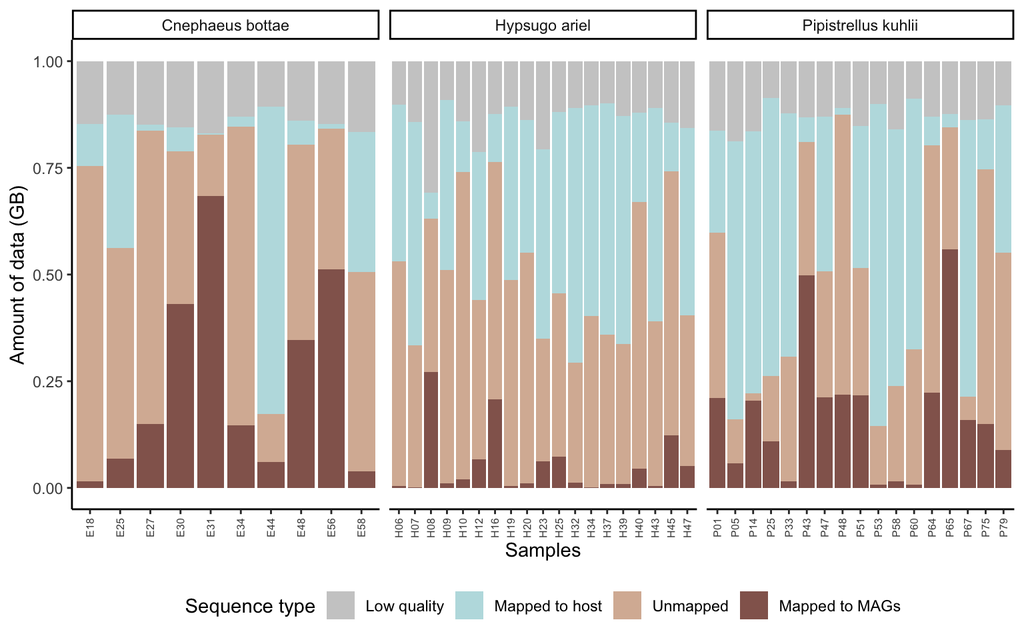

```r
microbial_fraction %>%
  select(sample,lowqual_bases,host_bases,unmapped_bases,mapped_bases) %>%
    pivot_longer(!sample, names_to = "fraction", values_to = "value") %>%
    group_by(sample) %>%
  mutate(value = value / sum(value)) %>%
  ungroup() %>%
    mutate(fraction = factor(fraction, levels = c("lowqual_bases","host_bases","unmapped_bases","mapped_bases"))) %>%
  inner_join(sample_metadata,by="sample") %>%
    ggplot(., aes(x = sample, y = value, fill=fraction)) +
  geom_bar(position="stack", stat = "identity") +
  scale_fill_manual(name="Sequence type",
                    breaks=c("lowqual_bases","host_bases","unmapped_bases","mapped_bases"),
                    labels=c("Low quality","Mapped to host","Unmapped","Mapped to MAGs"),
                    values=c("#CCCCCC", "#bcdee1", "#d8b8a3","#93655c"))+
  facet_grid(. ~ factor(Species, labels=c("Eb" = "Cnephaeus bottae", "Ha" = "Hypsugo ariel", "Pk" = "Pipistrellus kuhlii")), scales = "free")+
  labs(x = "Samples", y = "Amount of data (GB)") +
  theme_classic() +
  theme(axis.text.x = element_text(angle = 90, vjust = 0.5, hjust = 1, size=6),
        legend.position = "bottom")
```

```r
microbial_fraction %>%
  mutate(host_fraction=host_bases/(lowqual_bases+host_bases+unmapped_bases+mapped_bases)*100) %>%
  mutate(mapped_fraction=mapped_bases/(lowqual_bases+host_bases+unmapped_bases+mapped_bases)*100) %>%
  select(sample,host_fraction,mapped_fraction) %>%
    pivot_longer(!sample, names_to = "fraction", values_to = "value") %>%
  group_by(fraction) %>%
  summarise(min=min(value),max=max(value)) %>%
  tt()
```

[output not shown]

### 3.1.5 Estimated vs recovered proportion

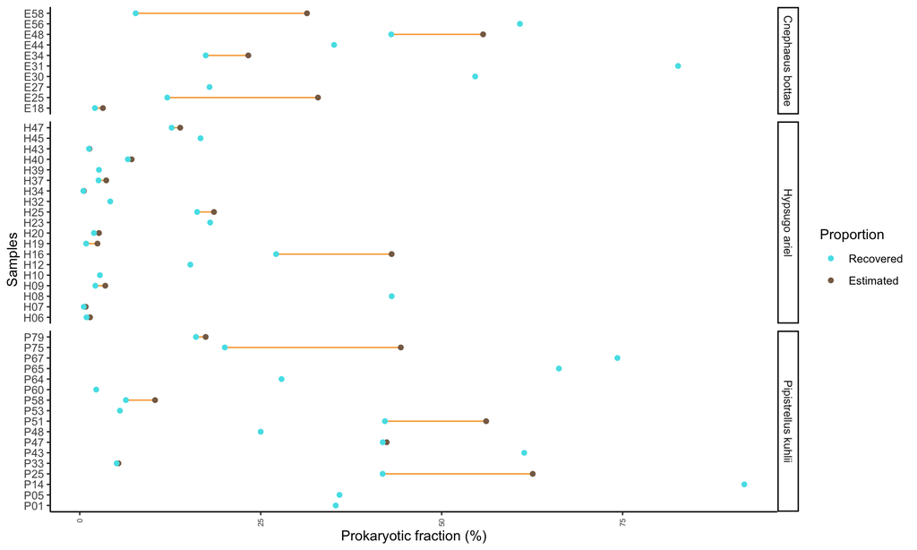

```r
microbial_fraction %>%
    mutate(mapped_microbial_fraction = ifelse(estimated_microbial_fraction == 0, 0, mapped_microbial_fraction)) %>%
    mutate(estimated_microbial_fraction = ifelse(estimated_microbial_fraction == 0, NA, estimated_microbial_fraction)) %>%
    mutate(estimated_microbial_fraction = ifelse(estimated_microbial_fraction < mapped_microbial_fraction, NA, estimated_microbial_fraction)) %>%
    mutate(estimated_microbial_fraction = ifelse(estimated_microbial_fraction > 100, 100, estimated_microbial_fraction)) %>%
  select(sample,estimated_microbial_fraction,mapped_microbial_fraction) %>%
    pivot_longer(!sample, names_to = "proportion", values_to = "value") %>%
    mutate(proportion = factor(proportion, levels = c("mapped_microbial_fraction","estimated_microbial_fraction"))) %>%
  inner_join(sample_metadata,by="sample") %>%
    ggplot(., aes(x = value, y = sample, color=proportion)) +
  geom_line(aes(group = sample), color = "#f8a538") +
  geom_point() +
  scale_color_manual(name="Proportion",
                    breaks=c("mapped_microbial_fraction","estimated_microbial_fraction"),
                    labels=c("Recovered","Estimated"),
                    values=c("#52e1e8", "#876b53"))+
  facet_grid(rows = vars(Species), space = "free", scales = "free",
           labeller = labeller(Species = c(Eb = "Cnephaeus bottae", Ha = "Hypsugo ariel", Pk = "Pipistrellus kuhlii")))+
  theme_classic() +
  labs(y = "Samples", x = "Prokaryotic fraction (%)") +
  theme(axis.text.x = element_text(angle = 90, vjust = 0.5, hjust = 1, size=6),legend.position = "right")
```

### 3.1.6 Domain-adjusted mapping rate

```r
microbial_fraction %>%
  mutate(damr=ifelse(mapped_microbial_fraction>estimated_microbial_fraction,100,mapped_microbial_fraction/estimated_microbial_fraction*100)) %>%
  inner_join(sample_metadata,by="sample") %>%
  summarise(mean=mean(damr),sd=sd(damr)) %>%
  tt()
```

| mean | sd |
| --- | --- |
| 84.89668 | 20.58994 |

```r
microbial_fraction %>%
  mutate(damr=ifelse(mapped_microbial_fraction>estimated_microbial_fraction,100,mapped_microbial_fraction/estimated_microbial_fraction*100)) %>%
  inner_join(sample_metadata,by="sample") %>%
  mutate(Species = factor(Species, levels = c("Eb", "Ha", "Pk"), labels = c("Cnephaeus bottae", "Hypsugo ariel", "Pipistrellus kuhlii"))) %>%
  group_by(Species) %>%
  summarise(mean=mean(damr),sd=sd(damr)) %>%
  tt()
```

| Species | mean | sd |
| --- | --- | --- |
| Cnephaeus bottae | 77.87083 | 28.17509 |
| Hypsugo ariel | 83.77217 | 18.58653 |
| Pipistrellus kuhlii | 90.28633 | 17.14514 |

```r
microbial_fraction %>%
  mutate(damr=ifelse(mapped_microbial_fraction>estimated_microbial_fraction,100,mapped_microbial_fraction/estimated_microbial_fraction*100)) %>%
  inner_join(sample_metadata,by="sample") %>%
  kruskal.test(damr ~ Species)
```

```
    Kruskal-Wallis rank sum test

data:  .
Kruskal-Wallis chi-squared = 558.6, df = 16, p-value < 2.2e-16
```

## 3.2 Amplicon

### 3.2.1 Taxonomy overview

```r
load("resources/amplicon/data_standard_filt.Rdata")
```

**Number of ASV**

```r
genome_metadata %>%
  nrow() %>%
  cat()
```

```
3250
```

**Number of phyla**

```r
genome_metadata %>%
  distinct(phylum) %>%
  nrow() %>%
  cat()
```

```
27
```

**Number of Archaea phyla**

```r
genome_metadata %>%
  filter(domain == "Archaea")%>%
  dplyr::select(phylum) %>%
  unique() %>%
  pull() %>%
  length()%>%
  cat()
```

```
4
```

```r
genome_metadata %>%
  filter(domain == "Archaea")%>%
  dplyr::select(phylum) %>%
  unique() %>%
  pull()
```

```
[1] "Halobacterota"    "Thermoplasmatota" "Euryarchaeota"    "Crenarchaeota"
```

**Number of Bacteria phyla**

```r
genome_metadata %>%
  filter(domain == "Bacteria")%>%
  dplyr::select(phylum) %>%
  unique() %>%
  pull() %>%
  length()%>%
  cat()
```

```
23
```

#### 3.2.1.1 Phylum level

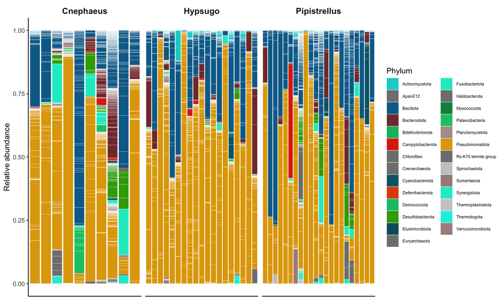

```r
genome_counts_filt %>%
  mutate_at(vars(-genome),  ~ . / sum(.)) %>%
  pivot_longer(-genome, names_to = "sample", values_to = "count") %>%
  left_join(., genome_metadata, by = join_by(genome == genome)) %>%
  left_join(., sample_metadata, by = join_by(sample == sample)) %>%
  filter(count > 0) %>% #filter 0 counts
  ggplot(., aes(
    x = sample,
    y = count,
    fill = phylum,
    group = phylum
  )) +
  geom_bar(stat = "identity",
           colour = "white",
           linewidth = 0.1) +
  scale_fill_manual(values = phylum_colors) +
  facet_nested( ~ factor(
    Species,
    labels = c("Eb" = "Cnephaeus", "Ha" = "Hypsugo", "Pk" = "Pipistrellus")
  ), scales = "free") +
  guides(fill = guide_legend(ncol = 1)) +
  theme(
    axis.text.x = element_blank(),
    axis.ticks.x = element_blank(),
    axis.title.x = element_blank(),
    panel.background = element_blank(),
    panel.border = element_blank(),
    panel.grid.major = element_blank(),
    panel.grid.minor = element_blank(),
    legend.text = element_text(size = 6),
    strip.background = element_rect(fill = "white"),
    strip.text = element_text(
      size = 12,
      lineheight = 0.6,
      face = "bold"
    ),
    axis.line = element_line(
      linewidth = 0.5,
      linetype = "solid",
      colour = "black"
    )
  ) +
  labs(fill = "Phylum", y = "Relative abundance", x = "Samples")+
  guides(fill = guide_legend(ncol = 2))
```

**Grouping low-abundance bacteria**

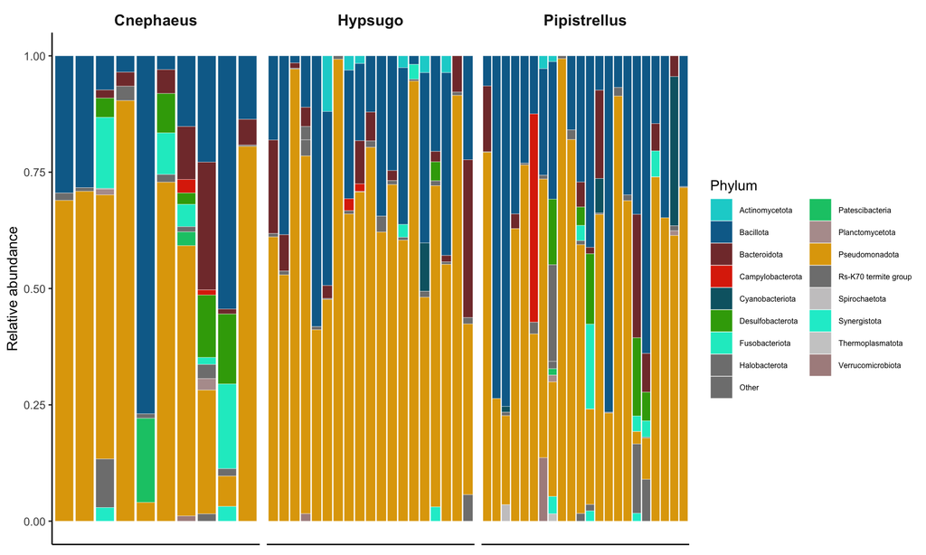

```r
p1 <- genome_counts_filt %>%
  mutate_at(vars(-genome), ~ . / sum(.)) %>%
  pivot_longer(-genome, names_to = "sample", values_to = "count") %>%
  left_join(genome_metadata, by = join_by(genome == genome)) %>%
  left_join(sample_metadata, by = join_by(sample == sample)) %>%
  filter(count > 0) %>%
group_by(sample, phylum) %>%
  mutate(total_abundance = sum(count)) %>%
  ungroup() %>%
  mutate(phylum = if_else(total_abundance < 0.01, "Other", phylum)) %>%
  group_by(sample, phylum, Species) %>%
  summarise(count = sum(count), .groups = "drop") %>%
   ggplot(aes(
    x = sample,
    y = count,
    fill = phylum,
    group = phylum
  )) +
  geom_bar(stat = "identity",
           colour = "white",
           linewidth = 0.1) +
  scale_fill_manual(values = c(phylum_colors, "Other" = "grey50"),
                    drop = FALSE)+
  facet_nested(~ factor(
    Species,
    labels = c("Eb" = "Cnephaeus", "Ha" = "Hypsugo", "Pk" = "Pipistrellus")
  ), scales = "free") +
  guides(fill = guide_legend(ncol = 1)) +
  theme(
    axis.text.x = element_blank(),
    axis.ticks.x = element_blank(),
    axis.title.x = element_blank(),
    panel.background = element_blank(),
    panel.border = element_blank(),
    panel.grid.major = element_blank(),
    panel.grid.minor = element_blank(),
    legend.text = element_text(size = 6),
    strip.background = element_rect(fill = "white"),
    strip.text = element_text(
      size = 12,
      lineheight = 0.6,
      face = "bold"
    ),
    axis.line = element_line(
      linewidth = 0.5,
      linetype = "solid",
      colour = "black"
    )
  ) +
  labs(fill = "Phylum", y = "Relative abundance", x = "Samples")+
  guides(fill = guide_legend(ncol = 2))

#ggsave("community_plot_grouped_standard.pdf", plot = p1, width = 12, height = 6)
p1
```

**Phylum relative abundances**

```r
phylum_summary <- genome_counts_filt %>%
  mutate_at(vars(-genome),  ~ . / sum(.)) %>%
  pivot_longer(-genome, names_to = "sample", values_to = "count") %>%
  left_join(sample_metadata, by = join_by(sample == sample)) %>%
  left_join(genome_metadata, by = join_by(genome == genome)) %>%
  group_by(sample, phylum, Species) %>%
  summarise(relabun = sum(count))
```

```r
phylum_summary %>%
  group_by(phylum) %>%
  summarise(
    Total_mean = mean(relabun * 100, na.rm = T),
    Total_sd = sd(relabun * 100, na.rm = T),
    Eb_mean = mean(relabun[Species == "Eb"] * 100, na.rm = T),
    Eb_sd = sd(relabun[Species == "Eb"] * 100, na.rm = T),
    Ha_mean = mean(relabun[Species == "Ha"] * 100, na.rm = T),
    Ha_sd = sd(relabun[Species == "Ha"] * 100, na.rm = T),
    Pk_mean = mean(relabun[Species == "Pk"] * 100, na.rm = T),
    Pk_sd = sd(relabun[Species == "Pk"] * 100, na.rm = T)
  ) %>%
  mutate(
    Total = str_c(round(Total_mean, 3), "±", round(Total_sd, 3)),
    Cnephaeus = str_c(round(Eb_mean, 3), "±", round(Eb_sd, 3)),
    Hypsugo = str_c(round(Ha_mean, 3), "±", round(Ha_sd, 3)),
    Pipistrellus = str_c(round(Pk_mean, 3), "±", round(Pk_sd, 3))
  ) %>%
  arrange(-Eb_mean) %>%
  dplyr::select(phylum, Total, Cnephaeus, Hypsugo, Pipistrellus) %>%
  tt()
```

| phylum | Total | Cnephaeus | Hypsugo | Pipistrellus |
| --- | --- | --- | --- | --- |
| Pseudomonadota | 58.827±25.938 | 53.556±30.577 | 67.53±18.837 | 53.708±28.067 |
| Bacillota | 26.432±20.949 | 25.457±23.76 | 22.92±16.074 | 29.909±23.606 |
| Bacteroidota | 4.871±7.764 | 5.564±8.462 | 5.333±8.497 | 4.157±7.072 |
| Fusobacteriota | 1.832±4.279 | 5.056±6.787 | 0.381±0.927 | 1.62±4.027 |
| Desulfobacterota | 2.108±4.598 | 4.45±5.809 | 0.327±0.939 | 2.581±5.422 |
| Patescibacteria | 0.478±2.558 | 2.197±5.659 | 0.05±0.151 | 0.067±0.295 |
| Rs-K70 termite group | 0.947±2.854 | 1.379±3.224 | 0.372±1.305 | 1.247±3.605 |
| Synergistota | 0.364±0.935 | 0.671±1.258 | 0.167±0.702 | 0.394±0.949 |
| Planctomycetota | 0.177±0.476 | 0.603±0.816 | 0.015±0.059 | 0.123±0.37 |
| Campylobacterota | 1.088±6.268 | 0.529±0.911 | 0.265±0.676 | 2.053±9.543 |
| Verrucomicrobiota | 0.338±1.919 | 0.137±0.347 | 0.095±0.368 | 0.639±2.904 |
| Cyanobacteriota | 1.062±4.766 | 0.118±0.29 | 0.64±2.365 | 1.856±6.928 |
| Elusimicrobiota | 0.022±0.126 | 0.106±0.28 | 0±0 | 0.002±0.01 |
| Actinomycetota | 0.779±1.853 | 0.101±0.266 | 1.617±2.797 | 0.362±0.634 |
| Deferribacterota | 0.009±0.049 | 0.043±0.107 | 0±0 | 0.001±0.005 |
| Halobacterota | 0.48±2.926 | 0.017±0.048 | 0.181±0.666 | 0.949±4.427 |
| Spirochaetota | 0.092±0.499 | 0.013±0.042 | 0.023±0.101 | 0.188±0.753 |
| Apal-E12 | 0.001±0.004 | 0.003±0.01 | 0±0 | 0±0 |
| Bdellovibrionota | 0.006±0.028 | 0±0 | 0.005±0.015 | 0.009±0.041 |
| Chloroflexi | 0.005±0.017 | 0±0 | 0.012±0.027 | 0.002±0.006 |
| Crenarchaeota | 0.002±0.011 | 0±0 | 0.002±0.009 | 0.003±0.014 |
| Deinococcota | 0.02±0.13 | 0±0 | 0.053±0.212 | 0±0 |
| Euryarchaeota | 0.024±0.124 | 0±0 | 0±0 | 0.056±0.186 |
| Myxococcota | 0.004±0.021 | 0±0 | 0.011±0.035 | 0.001±0.003 |
| Sumerlaeota | 0.001±0.004 | 0±0 | 0.002±0.007 | 0±0 |
| Thermoplasmatota | 0.031±0.221 | 0±0 | 0.001±0.003 | 0.072±0.336 |
| Thermotogota | 0±0.003 | 0±0 | 0±0 | 0.001±0.004 |

**Number of phyla in each bat species**

```r
phylum_summary <- genome_counts_filt %>%
  mutate_at(vars(-genome),~./sum(.)) %>%
  pivot_longer(-genome, names_to = "sample", values_to = "count") %>%
  left_join(sample_metadata, by = join_by(sample == sample)) %>%
  mutate(Species = factor(Species, levels = c("Eb", "Ha", "Pk"), labels = c("Cnephaeus bottae", "Hypsugo ariel", "Pipistrellus kuhlii"))) %>%
  left_join(genome_metadata, by = join_by(genome == genome)) %>%
  group_by(sample,domain,phylum,Species) %>%
  summarise(relabun=sum(count))

phylum_summary %>%
  filter(relabun > 0) %>%
  group_by(Species,domain) %>%
  summarise(n_phyla = n_distinct(phylum)) %>%
  tt()
```

| Species | domain | n_phyla |
| --- | --- | --- |
| Cnephaeus bottae | Archaea | 1 |
| Cnephaeus bottae | Bacteria | 17 |
| Hypsugo ariel | Archaea | 3 |
| Hypsugo ariel | Bacteria | 19 |
| Pipistrellus kuhlii | Archaea | 4 |
| Pipistrellus kuhlii | Bacteria | 20 |

#### 3.2.1.2 Family level

**Percentage of families in each group**

```r
family_summary <- genome_counts_filt %>%
  mutate_at(vars(-genome),  ~ . / sum(.)) %>%
  pivot_longer(-genome, names_to = "sample", values_to = "count") %>%
  left_join(sample_metadata, by = join_by(sample == sample)) %>%
  left_join(., genome_metadata, by = join_by(genome == genome)) %>%
  group_by(sample, phylum, family, Species) %>%
  summarise(relabun = sum(count))
```

```r
family_summary %>%
  group_by(phylum,family) %>%
  summarise(
    Eb_mean = mean(relabun[Species == "Eb"] * 100, na.rm = T),
    Eb_sd = sd(relabun[Species == "Eb"] * 100, na.rm = T),
    Ha_mean = mean(relabun[Species == "Ha"] * 100, na.rm = T),
    Ha_sd = sd(relabun[Species == "Ha"] * 100, na.rm = T),
    Pk_mean = mean(relabun[Species == "Pk"] * 100, na.rm = T),
    Pk_sd = sd(relabun[Species == "Pk"] * 100, na.rm = T)
  ) %>%
  mutate(
    Cnephaeus = str_c(round(Eb_mean, 3), "±", round(Eb_sd, 3)),
    Hypsugo = str_c(round(Ha_mean, 3), "±", round(Ha_sd, 3)),
    Pipistrellus = str_c(round(Pk_mean, 3), "±", round(Pk_sd, 3))
  ) %>%
  arrange(-Pk_mean) %>%
  dplyr::select(family, Cnephaeus, Hypsugo, Pipistrellus) %>%
  tt()
```

| phylum | family | Cnephaeus | Hypsugo | Pipistrellus |
| --- | --- | --- | --- | --- |
| Pseudomonadota | Enterobacteriaceae | 26.696±31.681 | 8.835±13.588 | 13.236±22.967 |
| Pseudomonadota | Morganellaceae | 0.286±0.615 | 4.137±6.829 | 9.532±19.056 |
| Pseudomonadota | Yersiniaceae | 0.222±0.476 | 9.423±14.297 | 6.636±18.125 |
| Bacillota | Enterococcaceae | 6.978±10.459 | 2.886±4.693 | 5.421±10.611 |
| Bacillota | Streptococcaceae | 0.512±0.901 | 2.154±3.463 | 4.843±15.641 |
| Pseudomonadota | Diplorickettsiaceae | 14.286±27.8 | 0.202±0.499 | 4.667±20.883 |
| Bacillota | Bacillaceae | 0.461±0.701 | 7.363±9.575 | 4.638±14.908 |
| Bacillota | Lachnospiraceae | 5.117±11.828 | 2.332±5.596 | 4.138±8.838 |
| Pseudomonadota | Rickettsiaceae | 0.048±0.147 | 6.599±15.053 | 4.098±13.243 |
| Pseudomonadota | Pasteurellaceae | 0.443±1.394 | 4.54±9.866 | 3.52±6.119 |
| Pseudomonadota | Vibrionaceae | 3.255±10.077 | 5.495±8.448 | 3.049±11.084 |
| Desulfobacterota | Desulfovibrionaceae | 4.398±5.781 | 0.286±0.935 | 2.515±5.329 |
| Bacillota | Mycoplasmataceae | 1.26±3.488 | 0.045±0.168 | 2.387±11.173 |
| Bacteroidota | Dysgonomonadaceae | 1.595±1.962 | 2.478±7.724 | 2.301±5.02 |
| Bacillota | Ruminococcaceae | 3.508±4.163 | 0.945±2.097 | 2.278±4.42 |
| Campylobacterota | Helicobacteraceae | 0.442±0.841 | 0±0 | 2.05±9.544 |
| Bacillota | Clostridiaceae | 1.502±2.586 | 1.234±4.078 | 1.75±4.45 |
| Fusobacteriota | Leptotrichiaceae | 3.604±6.968 | 0.218±0.727 | 1.352±3.946 |
| Rs-K70 termite group | NA | 1.379±3.224 | 0.372±1.305 | 1.247±3.605 |
| Pseudomonadota | Rhizobiaceae | 0.215±0.229 | 2.599±7.706 | 1.202±3.953 |
| Pseudomonadota | Burkholderiaceae | 0.254±0.546 | 2.297±7.944 | 1.186±3.201 |
| Cyanobacteriota | Microcystaceae | 0±0 | 0.003±0.014 | 1.047±4.878 |
| Pseudomonadota | Erwiniaceae | 0.043±0.099 | 1.272±2.659 | 1.034±1.874 |
| Bacillota | Vagococcaceae | 0.217±0.457 | 0.205±0.658 | 0.994±3.417 |
| Pseudomonadota | NA | 0.736±1.123 | 4.956±11.019 | 0.878±1.892 |
| Halobacterota | Methanosarcinaceae | 0.017±0.048 | 0±0 | 0.855±4.01 |
| Pseudomonadota | Acetobacteraceae | 0.204±0.38 | 2±7.283 | 0.832±2.495 |
| Bacteroidota | Weeksellaceae | 0.572±1.608 | 2.205±4.911 | 0.722±2.954 |
| Verrucomicrobiota | Simkaniaceae | 0±0 | 0±0 | 0.619±2.904 |
| Pseudomonadota | Pseudomonadaceae | 0.234±0.441 | 1.456±3.927 | 0.574±2.481 |

[output cut: 232 more lines]

#### 3.2.1.3 Genus level

**Percetage of genera in each species**

```r
genus_summary <- genome_counts_filt %>%
  mutate_at(vars(-genome),  ~ . / sum(.)) %>%
  pivot_longer(-genome, names_to = "sample", values_to = "count") %>%
  left_join(sample_metadata, by = join_by(sample == sample)) %>%
  left_join(genome_metadata, by = join_by(genome == genome)) %>%
  group_by(sample, phylum, genus, Species) %>%
  summarise(relabun = sum(count))

genus_summary %>%
  group_by(genus) %>%
  summarise(
    Eb_mean = mean(relabun[Species == "Eb"] * 100, na.rm = T),
    Eb_sd = sd(relabun[Species == "Eb"] * 100, na.rm = T),
    Ha_mean = mean(relabun[Species == "Ha"] * 100, na.rm = T),
    Ha_sd = sd(relabun[Species == "Ha"] * 100, na.rm = T),
    Pk_mean = mean(relabun[Species == "Pk"] * 100, na.rm = T),
    Pk_sd = sd(relabun[Species == "Pk"] * 100, na.rm = T)
  ) %>%
  mutate(
    Cnephaeus = str_c(round(Eb_mean, 3), "±", round(Eb_sd, 3)),
    Hypsugo = str_c(round(Ha_mean, 3), "±", round(Ha_sd, 3)),
    Pipistrellus = str_c(round(Pk_mean, 3), "±", round(Pk_sd, 3))
  ) %>%
  arrange(-Pk_mean) %>%
  dplyr::select(genus, Cnephaeus, Hypsugo, Pipistrellus) %>%
  left_join(., genome_metadata[c(3, 7)] %>% unique(), by = join_by(genus == genus)) %>%
  tt()
```

| genus | Cnephaeus | Hypsugo | Pipistrellus | phylum |
| --- | --- | --- | --- | --- |
| Serratia | 0.222±0.476 | 9.053±14.403 | 6.497±18.165 | Pseudomonadota |
| Morganella | 0.015±0.033 | 2.014±6.106 | 5.676±14.84 | Pseudomonadota |
| Enterococcus | 6.978±10.459 | 2.886±4.693 | 5.42±10.612 | Bacillota |
| Lactococcus | 0.511±0.895 | 2.038±3.505 | 4.831±15.637 | Bacillota |
| Bacillus | 0.435±0.69 | 7.278±9.503 | 4.626±14.907 | Bacillota |
| Rickettsiella | 14.286±27.8 | 0.11±0.44 | 4.463±20.908 | Pseudomonadota |
| Rickettsia | 0.048±0.147 | 6.599±15.053 | 4.098±13.243 | Pseudomonadota |
| Vibrio | 3.255±10.077 | 5.495±8.448 | 3.048±11.084 | Pseudomonadota |
| Enterobacter | 15.421±26.452 | 4.974±10.787 | 2.813±6.494 | Pseudomonadota |
| Lachnoclostridium | 3.641±9.837 | 0.525±2.016 | 2.808±7.314 | Bacillota |
| Klebsiella | 2.1±2.958 | 0.639±2.775 | 2.736±9.216 | Pseudomonadota |
| Proteus | 0.106±0.296 | 0.338±1.256 | 2.697±7.262 | Pseudomonadota |
| Vespertiliibacter | 0.443±1.394 | 1.874±2.993 | 2.603±5.092 | Pseudomonadota |
| Desulfovibrio | 4.184±5.541 | 0.278±0.931 | 2.395±5.102 | Desulfobacterota |
| Mycoplasma | 1.232±3.399 | 0.001±0.003 | 2.375±11.126 | Bacillota |
| Dysgonomonas | 1.534±1.883 | 2.435±7.724 | 2.25±5.037 | Bacteroidota |
| Helicobacter | 0.442±0.841 | 0±0 | 2.05±9.544 | Campylobacterota |
| Lelliottia | 0.102±0.203 | 0.046±0.098 | 1.801±5.685 | Pseudomonadota |
| Mangrovibacter | 3.928±9.942 | 0.012±0.037 | 1.604±6.392 | Pseudomonadota |
| Candidatus Soleaferrea | 1.146±2.28 | 0.734±1.963 | 1.581±3.896 | Bacillota |
| Sebaldella | 3.604±6.968 | 0.046±0.141 | 1.351±3.946 | Fusobacteriota |
| Microcystis PCC-7914 | 0±0 | 0.003±0.014 | 1.046±4.878 | Cyanobacteriota |
| Vagococcus | 0.217±0.457 | 0.205±0.658 | 0.994±3.417 | Bacillota |
| Candidatus Arthromitus | 0.561±1.774 | 1.059±4.077 | 0.925±4.056 | Bacillota |
| Burkholderia-Caballeronia-Paraburkholderia | 0±0 | 0.454±1.002 | 0.881±3.082 | Pseudomonadota |
| Providencia | 0.164±0.354 | 0.604±1.58 | 0.875±3.459 | Pseudomonadota |
| Methanimicrococcus | 0.017±0.048 | 0±0 | 0.855±4.01 | Halobacterota |
| Clostridium sensu stricto 1 | 0.877±1.977 | 0.155±0.539 | 0.826±2.049 | Bacillota |
| NA | 0.735±2.405 | 0.997±5.046 | 0.717±3.21 | Pseudomonadota |
| NA | 0.735±2.405 | 0.997±5.046 | 0.717±3.21 | Rs-K70 termite group |

[output cut: 471 more lines]

### 3.2.2 ASVs

**Number of ASVs and distinct taxonomy**

```r
bats = c("Eb", "Pk", "Ha")

total_asvs <- data.frame(
  Bat = character(),
  MAGs = numeric(),
  Phylum = numeric(),
  Family = numeric(),
  Genus = numeric()
)

preabs_table <- genome_counts_filt %>%
  mutate(across(-genome, ~ . / sum(.))) %>%
  column_to_rownames("genome") %>%
  mutate(across(everything(), ~ as.integer(. > 0))) %>%
  t() %>%
  as.data.frame() %>%
  rownames_to_column("sample") %>%
  left_join(sample_metadata[c("sample", "Species")], by = "sample") %>%
  group_by(Species) %>%
  summarize(across(-sample, sum), .groups = "drop") %>%
  column_to_rownames("Species") %>%
  t() %>%
  as.data.frame() %>%
  rownames_to_column("genome")  %>%
  left_join(genome_metadata, by = join_by("genome" == "genome"))
# %>%
#   filter(domain=="Bacteria")

phylum <- preabs_table %>%
  distinct(phylum)

family <- preabs_table %>%
  distinct(phylum, class, order, family)

genus <- preabs_table %>%
  distinct(phylum, class, order, family, genus)

total_asvs <- rbind(
  total_asvs,
  data.frame(
    Bat = "Total",
    ASVs = nrow(preabs_table),
    Phylum = nrow(phylum),
    Family = nrow(family),
    Genus = nrow(genus)
  )
)

for (bat in bats) {
  number <- preabs_table %>%
    select({{bat}}) %>%
    filter(. >= 1)

  phylum <- preabs_table %>%
    select({{bat}}, phylum) %>%
    filter(!!sym(bat) >= 1) %>%
    distinct(phylum)

  family <- preabs_table %>%
    select({{bat}}, phylum, class, order, family) %>%
    filter(!!sym(bat) >= 1) %>%
    distinct(phylum, class, order, family)

  genus <- preabs_table %>%
    select({{bat}}, phylum, class, order, family, genus) %>%
    filter(!!sym(bat) >= 1) %>%
    distinct(phylum, class, order, family, genus)

  total_asvs <- rbind(
    total_asvs,
    data.frame(
      Bat = bat,
      ASVs = nrow(number),
      Phylum = nrow(phylum),
      Family = nrow(family),
      Genus = nrow(genus)
    )
  )
}
```

```r
bats = c("Eb", "Pk", "Ha")

no_annotation <- data.frame(Bat = character(),
                            No_genus = numeric(),
                            No_species = numeric())

preabs_table <- genome_counts_filt %>%
  mutate(across(-genome, ~ . / sum(.))) %>%
  column_to_rownames("genome") %>%
  mutate(across(everything(), ~ as.integer(. > 0))) %>%
  t() %>%
  as.data.frame() %>%
  rownames_to_column("sample") %>%
  left_join(sample_metadata[c("sample", "Species")], by = "sample") %>%
  group_by(Species) %>%
  summarize(across(-sample, sum), .groups = "drop") %>%
  column_to_rownames("Species") %>%
  t() %>%
  as.data.frame() %>%
  rownames_to_column("genome")  %>%
  left_join(genome_metadata, by = join_by("genome" == "genome"))
# %>%
#   filter(domain=="Bacteria")

genus <- preabs_table  %>%
  filter(is.na(genus))

species <- preabs_table  %>%
  filter(is.na(species))

no_annotation <- rbind(no_annotation,
                       data.frame(
                         Bat = "Total",
                         No_genus = nrow(genus),
                         No_species = nrow(species)
                       ))

for (bat in bats) {
  number <- preabs_table %>%
    select({{bat}}) %>%
    filter(. >= 1)

  genus <- preabs_table %>%
    select({{bat}}, phylum, class, order, family, genus) %>%
    filter(!!sym(bat) >= 1) %>%
  filter(is.na(genus))

  species <- preabs_table %>%
    filter(!!sym(bat) >= 1) %>%
  filter(is.na(species))

  no_annotation <- rbind(no_annotation,
                         data.frame(
                           Bat = bat,
                           No_genus = nrow(genus),
                           No_species = nrow(species)
                         ))
}
```

**Total percentage of ASVs without genus-level annotation**

```r
nongenera <- genome_metadata %>%
#  filter(domain=="Bacteria") %>%
  filter(is.na(genus)) %>%
  summarize(ASV_nogenera = n()) %>%
  pull()
nasvs <- total_asvs %>%
  filter(Bat == "Total") %>%
  select(ASVs) %>%
  pull()
perct <- nongenera * 100 / nasvs
cat(perct)
```

```
30.24615
```

**Percentage of ASVs without genus-level annotation by phylum**

```r
total_asv_phylum <- genome_metadata %>%
#  filter(domain=="Bacteria") %>%
  group_by(phylum) %>%
  summarize(Total_ASVs = n())
genome_metadata %>%
 # filter(domain=="Bacteria") %>%
  filter(is.na(genus)) %>%
  group_by(phylum) %>%
  summarize(ASVs_nogenus = n()) %>%
  left_join(total_asv_phylum, by = join_by(phylum == phylum)) %>%
  mutate(Percentage_nogenus = 100 * ASVs_nogenus / Total_ASVs) %>%
  tt()
```

| phylum | ASVs_nogenus | Total_ASVs | Percentage_nogenus |
| --- | --- | --- | --- |
| Actinomycetota | 48 | 206 | 23.300971 |
| Apal-E12 | 1 | 1 | 100.000000 |
| Bacillota | 423 | 1162 | 36.402754 |
| Bacteroidota | 61 | 375 | 16.266667 |
| Bdellovibrionota | 4 | 7 | 57.142857 |
| Chloroflexi | 8 | 9 | 88.888889 |
| Cyanobacteriota | 13 | 46 | 28.260870 |
| Desulfobacterota | 36 | 165 | 21.818182 |
| Halobacterota | 1 | 30 | 3.333333 |
| Myxococcota | 1 | 4 | 25.000000 |
| Patescibacteria | 27 | 46 | 58.695652 |
| Planctomycetota | 56 | 65 | 86.153846 |
| Pseudomonadota | 269 | 1003 | 26.819541 |
| Rs-K70 termite group | 15 | 15 | 100.000000 |
| Spirochaetota | 2 | 5 | 40.000000 |
| Synergistota | 11 | 24 | 45.833333 |
| Thermoplasmatota | 2 | 3 | 66.666667 |
| Verrucomicrobiota | 5 | 30 | 16.666667 |

**Number of bacterial species**

```r
genome_metadata %>%
  filter(domain == "Bacteria")%>%
  dplyr::select(species) %>%
  unique() %>%
  pull() %>%
  length() %>%
  cat()
```

```
154
```

**Total percentage of MAGs without species-level annotation**

```r
nonspecies <- genome_metadata %>%
#  filter(domain=="Bacteria")%>%
  filter(is.na(species)) %>%
  summarize(ASV_nospecies = n()) %>%
  pull()
perct <- nonspecies * 100 / nasvs
cat(perct)
```

```
94.33846
```

**ASVs without species-level annotation**

```r
total_mag_phylum <- genome_metadata %>%
#  filter(domain=="Bacteria") %>%
  group_by(phylum) %>%
  summarize(ASVs_total = n())

genome_metadata %>%
#  filter(domain=="Bacteria")%>%
  filter(is.na(species)) %>%
  group_by(phylum) %>%
  summarize(ASVs_nospecies = n()) %>%
  left_join(total_mag_phylum, by = join_by(phylum == phylum)) %>%
  mutate(Species_annotated = ASVs_total - ASVs_nospecies) %>%
  mutate(Percentage_nospecies = 100 * ASVs_nospecies / ASVs_total) %>%
  mutate(Percentage_species = 100 - 100 * ASVs_nospecies / ASVs_total) %>%
  tt()
```

| phylum | ASVs_nospecies | ASVs_total | Species_annotated | Percentage_nospecies | Percentage_species |
| --- | --- | --- | --- | --- | --- |
| Actinomycetota | 185 | 206 | 21 | 89.80583 | 10.194175 |
| Apal-E12 | 1 | 1 | 0 | 100.00000 | 0.000000 |
| Bacillota | 1120 | 1162 | 42 | 96.38554 | 3.614458 |
| Bacteroidota | 355 | 375 | 20 | 94.66667 | 5.333333 |
| Bdellovibrionota | 7 | 7 | 0 | 100.00000 | 0.000000 |
| Campylobacterota | 9 | 12 | 3 | 75.00000 | 25.000000 |
| Chloroflexi | 9 | 9 | 0 | 100.00000 | 0.000000 |
| Crenarchaeota | 3 | 3 | 0 | 100.00000 | 0.000000 |
| Cyanobacteriota | 44 | 46 | 2 | 95.65217 | 4.347826 |
| Deferribacterota | 6 | 6 | 0 | 100.00000 | 0.000000 |
| Deinococcota | 5 | 5 | 0 | 100.00000 | 0.000000 |
| Desulfobacterota | 165 | 165 | 0 | 100.00000 | 0.000000 |
| Elusimicrobiota | 5 | 5 | 0 | 100.00000 | 0.000000 |
| Euryarchaeota | 3 | 3 | 0 | 100.00000 | 0.000000 |
| Fusobacteriota | 14 | 18 | 4 | 77.77778 | 22.222222 |
| Halobacterota | 30 | 30 | 0 | 100.00000 | 0.000000 |
| Myxococcota | 4 | 4 | 0 | 100.00000 | 0.000000 |
| Patescibacteria | 46 | 46 | 0 | 100.00000 | 0.000000 |
| Planctomycetota | 65 | 65 | 0 | 100.00000 | 0.000000 |
| Pseudomonadota | 912 | 1003 | 91 | 90.92722 | 9.072782 |
| Rs-K70 termite group | 15 | 15 | 0 | 100.00000 | 0.000000 |
| Spirochaetota | 5 | 5 | 0 | 100.00000 | 0.000000 |
| Sumerlaeota | 1 | 1 | 0 | 100.00000 | 0.000000 |
| Synergistota | 24 | 24 | 0 | 100.00000 | 0.000000 |
| Thermoplasmatota | 3 | 3 | 0 | 100.00000 | 0.000000 |
| Verrucomicrobiota | 30 | 30 | 0 | 100.00000 | 0.000000 |

### 3.2.3 Summary table

```r
bats = c("Eb", "Pk", "Ha")

single_sp <- data.frame(Bat = character(), Single_species = numeric())

# bacteria <- genome_metadata %>%
#  filter(domain=="Bacteria")

table_upset_analysis <- genome_counts_filt %>%
  mutate(across(-genome, ~ . / sum(.))) %>%
#  filter(genome %in% bacteria$genome) %>%
  column_to_rownames("genome") %>%
  mutate(across(everything(), ~ as.integer(. > 0))) %>%
  t() %>%
  as.data.frame() %>%
  rownames_to_column("sample") %>%
  left_join(sample_metadata[c("sample", "Species")], by = "sample") %>%
  group_by(Species) %>%
  summarize(across(-sample, sum), .groups = "drop") %>%
  column_to_rownames("Species") %>%
  mutate(across(everything(), ~ as.integer(. > 0))) %>%
  t() %>%
  as.data.frame() %>%
  rownames_to_column("sample")

unique_all <- table_upset_analysis %>%
  filter(rowSums(across(Eb:Pk)) == 1)

single_sp <- rbind(single_sp, data.frame(Bat = "Total",
                                         Single_species = nrow(unique_all)))

for (bat in bats) {
  unique <- table_upset_analysis %>%
    filter(rowSums(across(Eb:Pk)) == 1) %>%
    column_to_rownames(., "sample") %>%
    select(bat) %>%
    filter(. > 0) %>%
    nrow()
  single_sp <- rbind(single_sp, data.frame(Bat = bat, Single_species = unique))
}
```

```r
single_ind <- data.frame(Bat = character(), Single_individual = numeric())

freq_table <- genome_counts_filt %>%
  mutate(across(-genome, ~ . / sum(.))) %>%
#  filter(genome %in% bacteria$genome) %>%
  column_to_rownames("genome") %>%
  mutate(across(everything(), ~ as.integer(. > 0))) %>%
  t() %>%
  as.data.frame() %>%
  rownames_to_column("sample") %>%
  left_join(sample_metadata[c("sample", "Species")], by = "sample") %>%
  group_by(Species) %>%
  summarize(across(-sample, sum), .groups = "drop") %>%
  column_to_rownames("Species") %>%
  t() %>%
  as.data.frame() %>%
  rownames_to_column("asv")

singleton_filt <- freq_table %>%
  rowwise() %>%
  mutate(row_sum = sum(c_across(-asv))) %>%
  filter(row_sum == 1) %>%
  column_to_rownames(var = "asv")  %>%
  filter(row_sum == 1)

single_ind <- rbind(single_ind, data.frame(
  Bat = "Total",
  Single_individual = nrow(singleton_filt)
))

for (bat in bats) {
  singleton_filt <- freq_table %>%
    rowwise() %>%
    mutate(row_sum = sum(c_across(-asv))) %>%
    filter(row_sum == 1) %>%
    column_to_rownames(var = "asv")  %>%
    select(bat) %>%
    filter(. == 1)

  single_ind <- rbind(single_ind, data.frame(
    Bat = bat,
    Single_individual = nrow(singleton_filt)
  ))
}
```

```r
summary_table_ampli <- total_asvs %>%
  left_join(., no_annotation, by = "Bat") %>%
  left_join(., single_ind, by = "Bat") %>%
  left_join(., single_sp, by = "Bat") %>%
  mutate(Bat = recode(Bat,
                      Eb = "Cnephaeus bottae",
                      Ha = "Hypsugo ariel",
                      Pk = "Pipistrellus kuhlii"))
summary_table_ampli %>%
  tt()
```

| Bat | ASVs | Phylum | Family | Genus | No_genus | No_species | Single_individual | Single_species |
| --- | --- | --- | --- | --- | --- | --- | --- | --- |
| Total | 3250 | 27 | 298 | 646 | 983 | 3066 | 2467 | 2832 |
| Cnephaeus bottae | 1130 | 18 | 138 | 247 | 383 | 1076 | 693 | 858 |
| Pipistrellus kuhlii | 1341 | 24 | 197 | 364 | 425 | 1266 | 887 | 989 |
| Hypsugo ariel | 1310 | 22 | 215 | 437 | 287 | 1202 | 887 | 985 |

```r
total_asv <- genome_metadata %>%
#  filter(domain=="Bacteria") %>%
  nrow()
summary_table_ampli %>%
  select(-Phylum,-Family, -Genus) %>%
  rowwise() %>%
  mutate(ASV_perc=round(ASVs*100/total_asv, 2))%>%
  mutate(No_genus_perc=round(No_genus*100/ASVs, 2))%>%
  mutate(No_species_perc=round(No_species*100/ASVs, 2)) %>%
  mutate(Single_individual_perc=round(Single_individual*100/ASVs, 2))%>%
  mutate(Single_species_perc=round(Single_species*100/ASVs, 2)) %>%
  mutate(Single_individual_per_unique=round(Single_individual*100/Single_species, 2)) %>%
  select(1,7:12) %>%
  tt()
```

| Bat | ASV_perc | No_genus_perc | No_species_perc | Single_individual_perc | Single_species_perc | Single_individual_per_unique |
| --- | --- | --- | --- | --- | --- | --- |
| Total | 100.00 | 30.25 | 94.34 | 75.91 | 87.14 | 87.11 |
| Cnephaeus bottae | 34.77 | 33.89 | 95.22 | 61.33 | 75.93 | 80.77 |
| Pipistrellus kuhlii | 41.26 | 31.69 | 94.41 | 66.14 | 73.75 | 89.69 |
| Hypsugo ariel | 40.31 | 21.91 | 91.76 | 67.71 | 75.19 | 90.05 |

### 3.2.4 Archaea

**Number of ASV**

```r
genome_metadata %>%
  filter(domain == "Archaea")%>%
  nrow() %>%
  cat()
```

```
39
```

**Archaeal ASVs present in more than one individual**

```r
genome_archaea <- genome_metadata %>%
  filter(domain == "Archaea")

genome_counts_filt %>%
  filter(genome %in% genome_archaea$genome) %>%
  mutate(across(-genome, ~ ifelse(. > 0, 1, 0)))%>%
  mutate(count = rowSums(across(-genome))) %>%
  select(genome, count) %>%
  filter(count>1)
```

```
    genome count
1  ASV_125     2
2 ASV_1615     2
3 ASV_1719     2
```

**Presence of archaeal ASVs**

```r
genome_counts_filt %>%
  filter(genome %in% genome_archaea$genome) %>%
  select(
    genome,
    where(~ sum(. > 0) > 0)
  ) %>%
  mutate(across(-genome, ~ ifelse(. > 0, 1, 0))) %>%
  select(-genome) %>%
  colSums() %>%
  as.data.frame() %>%
  rename(archaea=1) %>%
  rownames_to_column("sample") %>%
  left_join(., sample_metadata[c(1,6)], by="sample") %>%
  tt()
```

| sample | archaea | species_name |
| --- | --- | --- |
| H45 | 1 | Hypsugo ariel |
| H43 | 1 | Hypsugo ariel |
| P75 | 1 | Pipistrellus kuhlii |
| H09 | 20 | Hypsugo ariel |
| P45 | 1 | Pipistrellus kuhlii |
| E48 | 1 | Eptesicus bottae |
| H34 | 1 | Hypsugo ariel |
| P09 | 1 | Pipistrellus kuhlii |
| P36 | 9 | Pipistrellus kuhlii |
| P58 | 2 | Pipistrellus kuhlii |
| E34 | 1 | Eptesicus bottae |
| P48 | 1 | Pipistrellus kuhlii |
| H12 | 1 | Hypsugo ariel |
| P47 | 1 | Pipistrellus kuhlii |

**Number of archaeal ASVs in each species**

```r
genome_counts_filt %>%
  filter(genome %in% genome_archaea$genome) %>%
  select(
    genome,
    where(~ sum(. > 0) > 0)
  ) %>%
  mutate(across(-genome, ~ ifelse(. > 0, 1, 0))) %>%
  select(-genome) %>%
  colSums() %>%
  as.data.frame() %>%
  rename(archaea=1) %>%
  rownames_to_column("sample") %>%
  left_join(., sample_metadata[c(1,6)], by="sample") %>%
  group_by(species_name) %>%
  summarise(asv=sum(archaea)) %>%
  tt()
```

| species_name | asv |
| --- | --- |
| Eptesicus bottae | 2 |
| Hypsugo ariel | 24 |
| Pipistrellus kuhlii | 16 |

**Number of individuals with archaeal ASVs**

```r
genome_counts_filt %>%
  filter(genome %in% genome_archaea$genome) %>%
  select(
    genome,
    where(~ sum(. > 0) > 0)
  ) %>%
  mutate(across(-genome, ~ ifelse(. > 0, 1, 0))) %>%
  select(-genome) %>%
  colSums() %>%
  as.data.frame() %>%
  rename(archaea=1) %>%
  rownames_to_column("sample") %>%
  left_join(., sample_metadata[c(1,6)], by="sample") %>%
  group_by(species_name) %>%
  summarise(indiv=n()) %>%
  tt()
```

| species_name | indiv |
| --- | --- |
| Eptesicus bottae | 2 |
| Hypsugo ariel | 5 |
| Pipistrellus kuhlii | 7 |

**Mean presence of archaeal ASVs**

```r
genome_counts_filt %>%
  filter(genome %in% genome_archaea$genome) %>%
  mutate(across(-genome, ~ ifelse(. > 0, 1, 0))) %>%
  select(-genome) %>%
  colSums() %>%
  as.data.frame() %>%
  rename(archaea=1) %>%
  rownames_to_column("sample") %>%
  left_join(., sample_metadata[c(1,6)], by="sample") %>%
  summarise(mean=mean(archaea), sd=sd(archaea)) %>%
  tt()
```

| mean | sd |
| --- | --- |
| 0.8235294 | 3.037801 |

**Mean presence of archaeal ASVs per species**

```r
genome_counts_filt %>%
  filter(genome %in% genome_archaea$genome) %>%
  mutate(across(-genome, ~ ifelse(. > 0, 1, 0))) %>%
  select(-genome) %>%
  colSums() %>%
  as.data.frame() %>%
  rename(archaea=1) %>%
  rownames_to_column("sample") %>%
  left_join(., sample_metadata[c(1,6)], by="sample") %>%
  group_by(species_name) %>%
  summarise(mean=mean(archaea), sd=sd(archaea)) %>%
  tt()
```

| species_name | mean | sd |
| --- | --- | --- |
| Eptesicus bottae | 0.2000000 | 0.421637 |
| Hypsugo ariel | 1.2631579 | 4.556340 |
| Pipistrellus kuhlii | 0.7272727 | 1.931735 |

```r
genome_archaea %>%
  distinct(genus) %>%
  tt()
```

| genus |
| --- |
| Methanimicrococcus |
| Candidatus Methanoplasma |
| Methanospirillum |
| Halalkalicoccus |
| NA |
| Halorussus |
| Haloterrigena |
| Methanobrevibacter |
| Methanocorpusculum |
| Candidatus Nitrocosmicus |
| Halolamina |
| Haladaptatus |
| Halostagnicola |
| Candidatus Nitrososphaera |
| Halovivax |
| Halohasta |
| Halomarina |
| Natronorubrum |
| Halomicrobium |
| Halococcus |
| Halobellus |

```r
genome_counts_filt %>%
  filter(genome %in% genome_archaea$genome) %>%
  select(
    genome,
    where(~ sum(. > 0) > 0)
  ) %>%
  mutate(across(-genome, ~ ifelse(. > 0, 1, 0))) %>%
  mutate(count = rowSums(across(-genome))) %>%
  select(genome, count) %>%
  arrange(-count)  %>%
  tt()
```

| genome | count |
| --- | --- |
| ASV_125 | 2 |
| ASV_1615 | 2 |
| ASV_1719 | 2 |
| ASV_110 | 1 |
| ASV_314 | 1 |
| ASV_532 | 1 |
| ASV_931 | 1 |
| ASV_1141 | 1 |
| ASV_1576 | 1 |
| ASV_1577 | 1 |
| ASV_1682 | 1 |
| ASV_1828 | 1 |
| ASV_1900 | 1 |
| ASV_2079 | 1 |
| ASV_2083 | 1 |
| ASV_2189 | 1 |
| ASV_2275 | 1 |
| ASV_2310 | 1 |
| ASV_2603 | 1 |
| ASV_2694 | 1 |
| ASV_2895 | 1 |
| ASV_3016 | 1 |
| ASV_3129 | 1 |
| ASV_3291 | 1 |
| ASV_3302 | 1 |
| ASV_3526 | 1 |
| ASV_3933 | 1 |
| ASV_3974 | 1 |
| ASV_4014 | 1 |
| ASV_4020 | 1 |
| ASV_4124 | 1 |
| ASV_4256 | 1 |
| ASV_4709 | 1 |
| ASV_5015 | 1 |
| ASV_5233 | 1 |
| ASV_5680 | 1 |
| ASV_5741 | 1 |
| ASV_6829 | 1 |
| ASV_6937 | 1 |